# mlco

Matthew Tan

2024-08-03

## Overview

This report utilizes machine learning algorithms to predict the exercise method of participants. The target variable is `classe` in the dataset, representing five different exercise methods. We will build a predictive model using the Random Forest algorithm and evaluate its performance.

## Load Required Libraries

```r
library(randomForest)
library(caret)
library(dplyr)
```

## Load the Dataset

We download and load the dataset from the provided URL.

## Download the training dataset

```r
train_url <- "https://d396qusza40orc.cloudfront.net/predmachlearn/pml-training.csv"
train_data <- read.csv(train_url)
```

## View the structure and summary of the dataset

```r
str(train_data)
```

```
## 'data.frame':    19622 obs. of  160 variables:
##  $ X                       : int  1 2 3 4 5 6 7 8 9 10 ...
##  $ user_name               : chr  "carlitos" "carlitos" "carlitos" "carlitos" ...
##  $ raw_timestamp_part_1    : int  1323084231 1323084231 1323084231 1323084232 1323084232 1323084232 1323084232 1323084232 1323084232 1323084232 ...
##  $ raw_timestamp_part_2    : int  788290 808298 820366 120339 196328 304277 368296 440390 484323 484434 ...
##  $ cvtd_timestamp          : chr  "05/12/2011 11:23" "05/12/2011 11:23" "05/12/2011 11:23" "05/12/2011 11:23" ...
##  $ new_window              : chr  "no" "no" "no" "no" ...
##  $ num_window              : int  11 11 11 12 12 12 12 12 12 12 ...
##  $ roll_belt               : num  1.41 1.41 1.42 1.48 1.48 1.45 1.42 1.42 1.43 1.45 ...
##  $ pitch_belt              : num  8.07 8.07 8.07 8.05 8.07 8.06 8.09 8.13 8.16 8.17 ...
##  $ yaw_belt                : num  -94.4 -94.4 -94.4 -94.4 -94.4 -94.4 -94.4 -94.4 -94.4 -94.4 ...
##  $ total_accel_belt        : int  3 3 3 3 3 3 3 3 3 3 ...
##  $ kurtosis_roll_belt      : chr  "" "" "" "" ...
##  $ kurtosis_picth_belt     : chr  "" "" "" "" ...
##  $ kurtosis_yaw_belt       : chr  "" "" "" "" ...
```

[output cut: 86 more lines]

```r
summary(train_data)
```

```
##        X          user_name         raw_timestamp_part_1 raw_timestamp_part_2
##  Min.   :    1   Length:19622       Min.   :1.322e+09    Min.   :   294
##  1st Qu.: 4906   Class :character   1st Qu.:1.323e+09    1st Qu.:252912
##  Median : 9812   Mode  :character   Median :1.323e+09    Median :496380
##  Mean   : 9812                      Mean   :1.323e+09    Mean   :500656
##  3rd Qu.:14717                      3rd Qu.:1.323e+09    3rd Qu.:751891
##  Max.   :19622                      Max.   :1.323e+09    Max.   :998801
##
##  cvtd_timestamp      new_window          num_window      roll_belt
##  Length:19622       Length:19622       Min.   :  1.0   Min.   :-28.90
##  Class :character   Class :character   1st Qu.:222.0   1st Qu.:  1.10
##  Mode  :character   Mode  :character   Median :424.0   Median :113.00
##                                        Mean   :430.6   Mean   : 64.41
##                                        3rd Qu.:644.0   3rd Qu.:123.00
##                                        Max.   :864.0   Max.   :162.00
##
##    pitch_belt          yaw_belt       total_accel_belt kurtosis_roll_belt
##  Min.   :-55.8000   Min.   :-180.00   Min.   : 0.00    Length:19622
##  1st Qu.:  1.7600   1st Qu.: -88.30   1st Qu.: 3.00    Class :character
##  Median :  5.2800   Median : -13.00   Median :17.00    Mode  :character
##  Mean   :  0.3053   Mean   : -11.21   Mean   :11.31
##  3rd Qu.: 14.9000   3rd Qu.:  12.90   3rd Qu.:18.00
##  Max.   : 60.3000   Max.   : 179.00   Max.   :29.00
##
##  kurtosis_picth_belt kurtosis_yaw_belt  skewness_roll_belt skewness_roll_belt.1
##  Length:19622        Length:19622       Length:19622       Length:19622
##  Class :character    Class :character   Class :character   Class :character
##  Mode  :character    Mode  :character   Mode  :character   Mode  :character
##
##
##
##
##  skewness_yaw_belt  max_roll_belt     max_picth_belt  max_yaw_belt
##  Length:19622       Min.   :-94.300   Min.   : 3.00   Length:19622
##  Class :character   1st Qu.:-88.000   1st Qu.: 5.00   Class :character
##  Mode  :character   Median : -5.100   Median :18.00   Mode  :character
##                     Mean   : -6.667   Mean   :12.92
##                     3rd Qu.: 18.500   3rd Qu.:19.00
##                     Max.   :180.000   Max.   :30.00
##                     NA's   :19216     NA's   :19216
```

[output cut: 289 more lines]

```
##  Min.   :-446.00   Min.   :-1280.0   Min.   :-896.0   Min.   :-973.0
##  1st Qu.:-182.00   1st Qu.: -616.0   1st Qu.:   2.0   1st Qu.: 191.0
##  Median : -39.00   Median : -378.0   Median : 591.0   Median : 511.0
##  Mean   : -55.29   Mean   : -312.6   Mean   : 380.1   Mean   : 393.6
##  3rd Qu.:  26.00   3rd Qu.:  -73.0   3rd Qu.: 737.0   3rd Qu.: 653.0
##  Max.   : 291.00   Max.   :  672.0   Max.   :1480.0   Max.   :1090.0
##
##     classe
##  Length:19622
##  Class :character
##  Mode  :character
##
##
##
##
```

The dataset contains various sensor measurements from participants and their exercise method (classe). We will predict the exercise method based on these measurements.

## Step 1: Data Cleaning

In the first step of data analysis, we clean the data. This includes removing near-zero variance predictors, removing columns with too many missing values, and eliminating irrelevant columns (e.g., timestamps, usernames).

```r
# Remove near-zero variance predictors
nzv <- nearZeroVar(train_data, saveMetrics = TRUE)
train_data <- train_data[, !nzv$nzv]

# Remove columns with too many missing values
train_data <- train_data[, colSums(is.na(train_data)) < nrow(train_data) * 0.95]

# Remove irrelevant columns
train_data <- train_data %>%
  select(-c(X, user_name, raw_timestamp_part_1, raw_timestamp_part_2, cvtd_timestamp))

# Convert 'classe' in 'training_data' to a factor
train_data$classe <- as.factor(train_data$classe)
```

During data cleaning, we removed columns with too many missing values and irrelevant features. This helps improve model performance and interpretability.

## Step 2: Data Preprocessing

Next, we split the data into training and testing sets and standardize the data. Standardization ensures each variable has a mean of 0 and a standard deviation of 1.

```r
# Split the data into training and testing sets
set.seed(123)
train_index <- createDataPartition(train_data$classe, p = 0.7, list = FALSE)
training_data <- train_data[train_index, ]
testing_data <- train_data[-train_index, ]

# Standardize the data
preproc <- preProcess(training_data[, -which(names(training_data) == "classe")], method = c("center", "scale"))
training_data_preprocessed <- predict(preproc, newdata = training_data)
testing_data_preprocessed <- predict(preproc, newdata = testing_data)
```

By standardizing the data, we ensure that the values of different features are on the same scale, which is especially important for algorithms that rely on distance metrics like Random Forest.

## Step 3: Model Building with Random Forest

We choose Random Forest to build the model because it performs well with data having high variance and multicollinearity.

```r
# Build the Random Forest model
rf_model <- randomForest(classe ~ ., data = training_data_preprocessed, importance = TRUE, ntree = 100)

# Evaluate variable importance
importance(rf_model)
```

```
##                              A         B         C         D         E
## num_window           16.930153 22.748865 25.068250 19.166055 20.795109
## roll_belt            16.615603 22.231989 20.281873 21.316753 18.794345
## pitch_belt           15.002281 22.501469 15.387961 14.303740 12.511487
## yaw_belt             16.468620 20.782436 18.397452 19.866747 15.609717
## total_accel_belt      6.648436  9.330411  6.995805  6.128770  6.543044
## gyros_belt_x          7.609966  9.277801  8.892521  7.179434  8.571917
## gyros_belt_y          6.074309  6.933704  8.045291  6.390482  6.615149
## gyros_belt_z          9.121573 13.898992 11.093680  9.571685 10.915748
## accel_belt_x          6.410136  6.588375  7.848424  7.504829  7.450685
## accel_belt_y          4.832585  5.017875  4.572251  4.802810  4.143870
## accel_belt_z          8.478113 10.095179 10.210832 11.244907  9.718212
## magnet_belt_x         7.853546 12.005890 10.771532  9.435134 10.793565
## magnet_belt_y         9.224765 10.636915 10.158596 11.037201  9.317522
## magnet_belt_z         9.563019 10.793936  9.038969 12.349390 10.470914
## roll_arm              9.583359 13.643057 12.453395 12.595220 10.642181
## pitch_arm             8.080933  9.264675  8.675076  8.518346  8.154739
## yaw_arm               8.977918 11.696346  9.496574 10.837348  8.374134
## total_accel_arm       3.827288  9.977782  8.556762  6.646892  8.135305
## gyros_arm_x           6.909146  8.178042  8.783122  9.071126  9.234634
## gyros_arm_y          10.010011 11.516710  9.632597 10.967065  9.116902
## gyros_arm_z           4.747406  7.986968  5.883560  6.732197  5.195661
## accel_arm_x           6.887918  7.558472  8.403159  8.608961  7.235955
## accel_arm_y           7.029929  9.320546  6.753798  8.891738  5.937523
## accel_arm_z           5.821282  6.708376  7.942688  7.482576  6.582803
## magnet_arm_x          7.329646  7.282267  8.156017  7.962254  6.663056
## magnet_arm_y          5.949977  7.050640  8.417693  7.898235  5.541302
## magnet_arm_z          7.868264  8.475314  8.502469  7.830407  7.189562
## roll_dumbbell         9.743122 12.129802 12.462267 12.471830 12.849769
## pitch_dumbbell        4.795169  8.792099  7.296991  6.396392  6.139544
## yaw_dumbbell          9.551736 11.722025 11.363849 11.076830  9.571479
## total_accel_dumbbell  7.371851 11.926897  9.356846  9.626107 12.802557
## gyros_dumbbell_x      8.907598  8.734424  7.607030  8.980214  8.107887
## gyros_dumbbell_y      7.880653  8.992546 11.227029  7.689706  7.539133
## gyros_dumbbell_z      6.774674 10.528211  7.861769  5.926669  8.221972
## accel_dumbbell_x      7.577212 10.209237  9.028017  7.216992  9.063436
## accel_dumbbell_y     12.738959 12.437384 15.473350 13.001201 12.950449
## accel_dumbbell_z     10.030357 11.143589 11.104573 11.482403 12.078526
## magnet_dumbbell_x     9.719448 11.387601 13.270070 11.307565  9.882652
## magnet_dumbbell_y    15.433768 15.130598 18.141016 15.614570 12.875889
```

[output cut: 53 more lines]

```
## magnet_dumbbell_y               17.824114        462.79220
## magnet_dumbbell_z               21.243968        449.82737
## roll_forearm                    12.208724        332.40695
## pitch_forearm                   16.228965        504.08264
## yaw_forearm                     11.760393         92.79908
## total_accel_forearm             10.763329         56.53138
## gyros_forearm_x                 11.579093         41.04705
## gyros_forearm_y                 12.942418         80.92287
## gyros_forearm_z                 12.767379         50.67952
## accel_forearm_x                 10.675991        208.68704
## accel_forearm_y                 10.041504         79.81115
## accel_forearm_z                 12.093584        162.06636
## magnet_forearm_x                 9.222090        139.45188
## magnet_forearm_y                10.161417        126.09058
## magnet_forearm_z                14.693668        164.69968
```

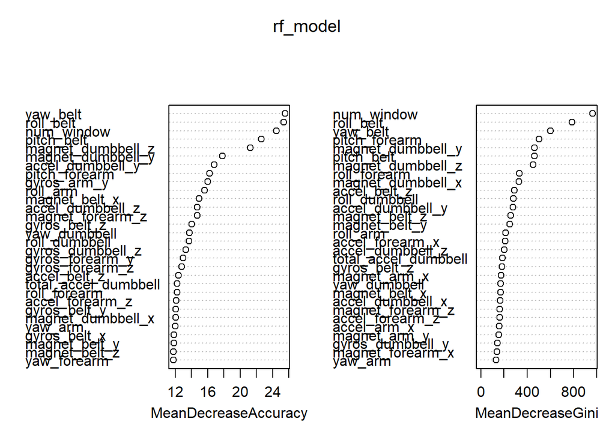

```r
varImpPlot(rf_model)
```

The Random Forest model can handle high-dimensional data while automatically computing the importance of features, helping us identify key variables that influence the prediction results. The varImpPlot provides a clear view of the most contributing variables to the predictions.

## Step 4: Cross-Validation

To evaluate the model’s stability and performance, we employ 10-fold cross-validation. Cross-validation helps reduce the risk of overfitting and provides a reliable estimate of the model’s generalization ability.

```r
# Set up cross-validation
train_control <- trainControl(method = "cv", number = 10)

# Train the model using cross-validation
set.seed(123)
cv_model <- train(classe ~ ., data = training_data_preprocessed, method = "rf", trControl = train_control, tuneLength = 3)

# Print the cross-validation results
print(cv_model)
```

```
## Random Forest
##
## 13737 samples
##    53 predictor
##     5 classes: 'A', 'B', 'C', 'D', 'E'
##
## No pre-processing
## Resampling: Cross-Validated (10 fold)
## Summary of sample sizes: 12362, 12363, 12364, 12364, 12364, 12363, ...
## Resampling results across tuning parameters:
##
##   mtry  Accuracy   Kappa
##    2    0.9946125  0.9931848
##   27    0.9969425  0.9961326
##   53    0.9961414  0.9951191
##
## Accuracy was used to select the optimal model using the largest value.
## The final value used for the model was mtry = 27.
```

By using 10-fold cross-validation, we obtain a stable performance evaluation result of the model, which helps enhance the model’s generalization ability.

## Step 5: Evaluate Model Performance

Evaluate the model performance on the test set using predictions. We’ll use the confusion matrix to measure the model’s accuracy and calculate the out-of-sample error rate.

```r
# Predict on the testing set
predictions <- predict(rf_model, newdata = testing_data_preprocessed)

# Use a confusion matrix to evaluate accuracy
confusion_matrix <- confusionMatrix(predictions, testing_data_preprocessed$classe)
print(confusion_matrix)
```

```
## Confusion Matrix and Statistics
##
##           Reference
## Prediction    A    B    C    D    E
##          A 1674    2    0    0    0
##          B    0 1133    1    0    0
##          C    0    4 1025    2    0
##          D    0    0    0  962    4
##          E    0    0    0    0 1078
##
## Overall Statistics
##
##                Accuracy : 0.9978
##                  95% CI : (0.9962, 0.9988)
##     No Information Rate : 0.2845
##     P-Value [Acc > NIR] : < 2.2e-16
##
##                   Kappa : 0.9972
##
##  Mcnemar's Test P-Value : NA
##
## Statistics by Class:
##
##                      Class: A Class: B Class: C Class: D Class: E
## Sensitivity            1.0000   0.9947   0.9990   0.9979   0.9963
## Specificity            0.9995   0.9998   0.9988   0.9992   1.0000
## Pos Pred Value         0.9988   0.9991   0.9942   0.9959   1.0000
## Neg Pred Value         1.0000   0.9987   0.9998   0.9996   0.9992
## Prevalence             0.2845   0.1935   0.1743   0.1638   0.1839
## Detection Rate         0.2845   0.1925   0.1742   0.1635   0.1832
## Detection Prevalence   0.2848   0.1927   0.1752   0.1641   0.1832
## Balanced Accuracy      0.9998   0.9973   0.9989   0.9986   0.9982
```

```r
# Calculate expected out-of-sample error
oob_error <- rf_model$err.rate[rf_model$ntree, "OOB"]
cat("Out-of-sample error rate:", oob_error, "\n")
```

```
## Out-of-sample error rate: 0.003785397
```

The confusion matrix shows the model’s prediction accuracy on the test set. Additionally, the Out-of-Bag (OOB) Error of Random Forest provides an effective estimate of the model’s generalization error. The OOB error rate reflects the model’s predictive capability on unseen data.

## Step 6: Predict on New Test Cases

Finally, we use the trained model to predict new test data

```r
# Download the test dataset
test_url <- "https://d396qusza40orc.cloudfront.net/predmachlearn/pml-testing.csv"
test_data <- read.csv(test_url)

# Ensure columns of test data match those of training data
common_columns <- intersect(names(training_data_preprocessed), names(test_data))
test_data <- test_data[, common_columns]

# Add any missing columns in test_data that are present in training_data_preprocessed
missing_columns <- setdiff(names(training_data_preprocessed), names(test_data))
for (col in missing_columns) {
  test_data[[col]] <- NA
}

# Reorder columns of test_data to match those in training_data_preprocessed
test_data <- test_data[, names(training_data_preprocessed)]

# Preprocess the test data
test_data_preprocessed <- predict(preproc, newdata = test_data)

# Make predictions on the test data using the cross-validated model
test_predictions <- predict(cv_model, newdata = test_data_preprocessed)
print(test_predictions)
```

```
##  [1] B A B A A E D B A A B C B A E E A B B B
## Levels: A B C D E
```

In the steps above, we ensure that the test data’s features are consistent with those of the training data and preprocess the data using the pre-processing model. Finally, we use the cross-validated model to predict new test data.